# Domácí úkol 4 - Stratifikovaný výběr

Pavel Pavlík

20. 11. 2025

## Načtení dat a definice proměnných

```r
mzdy <- read.table("Mzdy.txt", sep=",", header = TRUE)
mzdy$vzdel <- as.factor(mzdy$vzdel)
```

```r
mm <- 9
n <- 50 + abs(mm - 6) * 10
N <- nrow(mzdy)

true_mean <- mean(mzdy$Mzda)
popsize <- table(mzdy$vzdel)
true_mean_strat <- tapply(mzdy$Mzda, mzdy$vzdel, mean)
pop_var_strat <- tapply(mzdy$Mzda, mzdy$vzdel, var)
pop_sd_strat <- sqrt(pop_var_strat)

cat(paste("Celkový rozsah populace N =", N))
```

```
## Celkový rozsah populace N = 1134
```

```r
cat(paste("\nCelkový rozsah výběru n =", n))
```

```
##
## Celkový rozsah výběru n = 80
```

## i) Rozklad rozptylu

```r
aov_model <- aov(Mzda ~ vzdel, data = mzdy)
aov_summary <- summary(aov_model)
print(aov_summary)
```

```
##               Df   Sum Sq   Mean Sq F value Pr(>F)
## vzdel          3 4.41e+10 1.470e+10     898 <2e-16 ***
## Residuals   1130 1.85e+10 1.637e+07
## ---
## Signif. codes:  0 '***' 0.001 '**' 0.01 '*' 0.05 '.' 0.1 ' ' 1
```

```r
ss_between <- aov_summary[[1]]["Sum Sq"] [1, 1]
ss_within <- aov_summary[[1]]["Sum Sq"] [2, 1]
ss_total <- ss_between + ss_within

prop_between <- ss_between / ss_total
prop_within <- ss_within / ss_total

cat(paste("\nCelkový rozptyl (Sum of Squares):", round(ss_total)))
```

```
##
## Celkový rozptyl (Sum of Squares): 62601947243
```

```r
cat(paste("\nMeziskupinový rozptyl (vysvětlený vzděláním):", round(ss_between), "->", scales::percent(prop_between)))
```

```
##
## Meziskupinový rozptyl (vysvětlený vzděláním): 44102586671 -> 70%
```

```r
cat(paste("\nVnitroskupinový rozptyl (nevysvětlený):", round(ss_within), "->", scales::percent(prop_within)))
```

```
##
## Vnitroskupinový rozptyl (nevysvětlený): 18499360572 -> 30%
```

**Závěr:** Jak je vidět z analýzy, vzdělání vysvětluje přibližně 70% celkové variability mezd, což je významný podíl. To naznačuje, že stratifikace podle vzdělání bude efektivní.

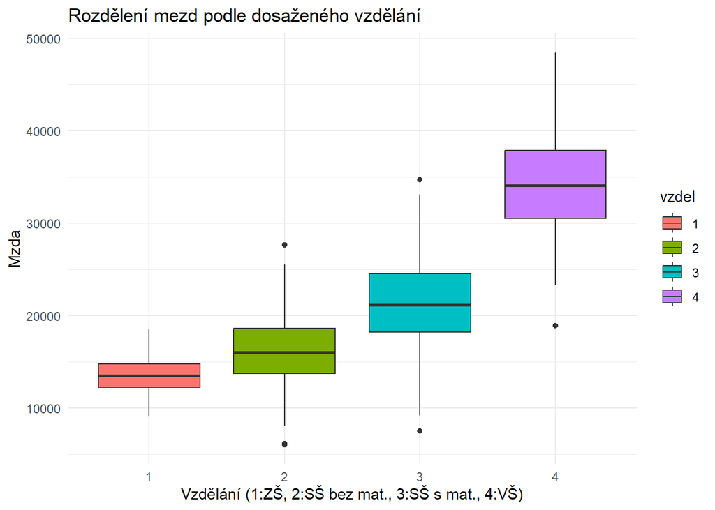

```r
ggplot(data = mzdy, aes(x = vzdel, y = Mzda, fill = vzdel)) +
  geom_boxplot() +
  labs(title = "Rozdělení mezd podle dosaženého vzdělání",
       x = "Vzdělání (1:ZŠ, 2:SŠ bez mat., 3:SŠ s mat., 4:VŠ)",
       y = "Mzda") +
  theme_minimal()
```

## ii) Alokace výběru

```r
# a) Rovnoměrná alokace (celá čísla, upravíme součet)
base_rov <- floor(n / length(popsize))
rov_aloc <- rep(base_rov, length(popsize))
rov_aloc[1] <- rov_aloc[1] + (n - sum(rov_aloc))

# b) Proporcionální alokace
prop_aloc <- round(n * popsize / N)
prop_aloc[1] <- prop_aloc[1] + (n - sum(prop_aloc))

# c) Optimální (Neymanova) alokace
numerator <- popsize * pop_sd_strat
opt_aloc <- round(n * numerator / sum(numerator))
opt_aloc[1] <- opt_aloc[1] + (n - sum(opt_aloc))

alokace_df <- data.frame(
  Stratum = c("1_ZS", "2_SS_bez_mat", "3_SS_s_mat", "4_VS"),
  Velikost_populace_Nh = popsize,
  Rovnomerna = rov_aloc,
  Proporcionalni = prop_aloc,
  Optimalni = opt_aloc
)

kable(alokace_df, caption = "Přehled alokací výběru")
```

Přehled alokací výběru

| Stratum | Velikost_populace_Nh.Var1 | Velikost_populace_Nh.Freq | Rovnomerna | Proporcionalni.Var1 | Proporcionalni.Freq | Optimalni.Var1 | Optimalni.Freq |
| --- | --- | --- | --- | --- | --- | --- | --- |
| 1_ZS | 1 | 125 | 20 | 1 | 9 | 1 | 4 |
| 2_SS_bez_mat | 2 | 442 | 20 | 2 | 31 | 2 | 28 |
| 3_SS_s_mat | 3 | 408 | 20 | 3 | 29 | 3 | 33 |
| 4_VS | 4 | 159 | 20 | 4 | 11 | 4 | 15 |

```r
get_strat_estimates <- function(sample_data, aloc_vector, pop_sizes, pop_means, total_N, total_n, name) {

  sample_data$vzdel <- factor(sample_data$vzdel, levels = names(pop_sizes))

  summary_stats <- sample_data %>%
    group_by(vzdel, .drop = FALSE) %>%
    summarise(
      vyb_prum = mean(Mzda, na.rm = TRUE),
      vyb_var = var(Mzda, na.rm = TRUE)
    ) %>%
    arrange(vzdel)

  vyb_prum_strat <- summary_stats$vyb_prum
  vyb_var_strat <- summary_stats$vyb_var

  vyb_prum_strat[is.na(vyb_prum_strat)] <- 0
  vyb_var_strat[is.na(vyb_var_strat)] <- 0

  odh_prum_celkem <- sum(pop_sizes * vyb_prum_strat) / total_N

  D_Y_hat_h <- ifelse(aloc_vector > 0, (1 - aloc_vector / pop_sizes) * vyb_var_strat / aloc_vector, 0)

  D_Y_hat_celkem <- sum(pop_sizes^2 * D_Y_hat_h, na.rm = TRUE) / total_N^2

  ci_celkem_d <- odh_prum_celkem - qt(0.975, total_n - 1) * sqrt(D_Y_hat_celkem)
  ci_celkem_h <- odh_prum_celkem + qt(0.975, total_n - 1) * sqrt(D_Y_hat_celkem)

  se_strat <- sqrt(D_Y_hat_h)
  t_val <- ifelse(aloc_vector >= 2, qt(0.975, aloc_vector - 1), NA)
  ci_strat_d <- vyb_prum_strat - t_val * se_strat
  ci_strat_h <- vyb_prum_strat + t_val * se_strat
  sirka_ci_strat <- ci_strat_h - ci_strat_d

  dostatecna_presnost <- ifelse(is.na(sirka_ci_strat), FALSE, sirka_ci_strat <= (0.10 * pop_means))

  strata_results <- data.frame(
    Stratum = names(pop_sizes),
    Odh_prumer = round(vyb_prum_strat),
    Pop_prumer = round(pop_means),
    CI_dolni = round(ci_strat_d),
    CI_horni = round(ci_strat_h),
    Sirka_CI = round(sirka_ci_strat),
    Presnost_OK = dostatecna_presnost
  )

  list(
    name = name,
    overall_ci = c(ci_celkem_d, ci_celkem_h),
    overall_ci_width = ci_celkem_h - ci_celkem_d,
    strata_results_table = strata_results
  )
}
```

### 1. Prostý náhodný výběr (PNV)

```r
set.seed(123)
pnv_sample <- mzdy[sample(1:N, n), ]

odh_prum_pnv <- mean(pnv_sample$Mzda)
odh_var_pnv <- (1 - n / N) * var(pnv_sample$Mzda) / n
ci_pnv_d <- odh_prum_pnv - qt(0.975, n - 1) * sqrt(odh_var_pnv)
ci_pnv_h <- odh_prum_pnv + qt(0.975, n - 1) * sqrt(odh_var_pnv)
sirka_pnv <- ci_pnv_h - ci_pnv_d
```

### 2. Stratifikovaný výběr

```r
set.seed(123)
# Výběry
r_strata <- strata(mzdy, stratanames = c("vzdel"), size = rov_aloc, method = "srswor")
r_sample <- getdata(mzdy, r_strata)

p_strata <- strata(mzdy, stratanames = c("vzdel"), size = prop_aloc, method = "srswor")
p_sample <- getdata(mzdy, p_strata)

o_strata <- strata(mzdy, stratanames = c("vzdel"), size = opt_aloc, method = "srswor")
o_sample <- getdata(mzdy, o_strata)

# Výpočty
results_rov <- get_strat_estimates(r_sample, rov_aloc, popsize, true_mean_strat, N, n, "Rovnoměrná")
results_prop <- get_strat_estimates(p_sample, prop_aloc, popsize, true_mean_strat, N, n, "Proporcionální")
results_opt <- get_strat_estimates(o_sample, opt_aloc, popsize, true_mean_strat, N, n, "Optimální")

all_results <- list(results_rov, results_prop, results_opt)
```

### Porovnání přesnosti výběrových plánů

```r
comparison_df <- data.frame(
  Metoda = c("PNV", results_rov$name, results_prop$name, results_opt$name),
  Srika_CI = c(sirka_pnv, results_rov$overall_ci_width, results_prop$overall_ci_width, results_opt$overall_ci_width)
)

kable(comparison_df, caption = "Srovnání šířky CI pro odhad celkové průměrné mzdy", digits = 2)
```

Srovnání šířky CI pro odhad celkové průměrné mzdy

| Metoda | Srika_CI |
| --- | --- |
| PNV | 2926.98 |
| Rovnoměrná | 1927.12 |
| Proporcionální | 1847.05 |
| Optimální | 1807.50 |

**Závěr k přesnosti odhadu celkového průměru:** * **Povede využití stratifikovaného výběru k zvýšení přesnosti?** Ano, všechny tři metody stratifikovaného výběru vedou k užšímu intervalu spolehlivosti (vyšší přesnosti) než prostý náhodný výběr. * **Tratíme hodně na přesnosti, když použijeme proporcionální alokaci místo optimální?** Rozdíl v přesnosti mezi optimální a proporcionální alokací je v tomto případě malý. Optimální alokace je sice teoreticky nejpřesnější, ale proporcionální je často jednodušší na implementaci a poskytuje velmi podobné výsledky, pokud se rozptyly ve stratech příliš neliší.